# Deliverable

By the deadline provided in the course shell, please complete the Jupyter notebook, convert it to PDF (In Chrome: File>Print>Save as PDF) and upload to the assignment folder.

Also upload the Jupyter Notebook document (File >Download > Download .ipynb)

**Note**: 10% penalty per day for late submission and after 72 hours 0 will be assigned

**Total mark**: 10 points

**Hint**: You can use codes of [Lab 6](https://github.com/tofighi/ITM760/blob/main/Lab6.ipynb), [Lab 7](https://github.com/tofighi/ITM760/blob/main/Lab7.ipynb), [Lab 8](https://github.com/tofighi/ITM760/blob/main/Lab8.ipynb) and to complete the project.

# Objective

The objective of this project is to gain hands-on experience using Python (one of the most popular tools for data mining and machine learning) to build models from real world datasets. You will also evaluate different data mining algorithms in terms of accuracy and run time.

[Dataset: News Popularity](https://github.com/tofighi/ITM760/blob/main/dataset/online_news_popularity.csv?raw=true)

# Description

Your job is to first apply exploratory analysis on this dataset. Split this dataset into a training set (70%) and a test set (30%) (Hint: take a look at parameters [here](https://scikit-learn.org/stable/modules/generated/sklearn.model_selection.train_test_split.html).The other parameters rather than `test_size` can be similar to the labs.

Then, apply each of the following algorithms to learn a model from the training set and classify the examples in the test set.

- SVM
- k-Nearest Neighbor
- Decision Tree

The above algorithms must be performed on the following dataset.

Use all 58 predictive attributes of the dataset for classification.

Report the classification accuracy and run time for training the model (`fit` function, such as `clf.fit(X_train,y_train)`) when you run the code (you can use [this code](https://stackoverflow.com/a/16414144)) for runtime of each algorithm on each data set. An example of runtime for a for loop is given [here](https://colab.research.google.com/drive/1aQ-iCWSeyA-pn2pH6CjaqsWuGEpqKCOt?usp=sharing).

Discuss the results and determine if there is an overall winner in terms of accuracy (misclassification rates) and run time. Apply relevant data cleaning (dropping non-predictive columns) and data transformation (scaling attributes) techniques (similar to labs).

# Dataset : Online News Popularity

The dataset is downloaded to your environment using the following code.

This dataset summarizes a set of features about articles published by Mashable in a period of two years. The goal is to predict `the number of shares` in social networks (popularity).

## Attribute Information:

Number of Attributes: 61 (58 predictive attributes, 2 non-predictive, 1 target class)

1. url: URL of the article (non-predictive)
2. timedelta: Days between the article publication and the dataset acquisition (non-predictive)
3. n_tokens_title: Number of words in the title
4. n_tokens_content: Number of words in the content
5. n_unique_tokens: Rate of unique words in the content
6. n_non_stop_words: Rate of non-stop words in the content
7. n_non_stop_unique_tokens: Rate of unique non-stop words in the content
8. num_hrefs: Number of links
9. num_self_hrefs: Number of links to other articles published by Mashable
10. num_imgs: Number of images
11. num_videos: Number of videos
12. average_token_length: Average length of the words in the content
13. num_keywords: Number of keywords in the metadata
14. data_channel_is_lifestyle: Is data channel 'Lifestyle'?
15. data_channel_is_entertainment: Is data channel 'Entertainment'?
16. data_channel_is_bus: Is data channel 'Business'?
17. data_channel_is_socmed: Is data channel 'Social Media'?
18. data_channel_is_tech: Is data channel 'Tech'?
19. data_channel_is_world: Is data channel 'World'?
20. kw_min_min: Worst keyword (min. shares)
21. kw_max_min: Worst keyword (max. shares)
22. kw_avg_min: Worst keyword (avg. shares)
23. kw_min_max: Best keyword (min. shares)
24. kw_max_max: Best keyword (max. shares)
25. kw_avg_max: Best keyword (avg. shares)
26. kw_min_avg: Avg. keyword (min. shares)
27. kw_max_avg: Avg. keyword (max. shares)
28. kw_avg_avg: Avg. keyword (avg. shares)
29. self_reference_min_shares: Min. shares of referenced articles in Mashable
30. self_reference_max_shares: Max. shares of referenced articles in Mashable
31. self_reference_avg_sharess: Avg. shares of referenced articles in Mashable
32. weekday_is_monday: Was the article published on a Monday?
33. weekday_is_tuesday: Was the article published on a Tuesday?
34. weekday_is_wednesday: Was the article published on a Wednesday?
35. weekday_is_thursday: Was the article published on a Thursday?
36. weekday_is_friday: Was the article published on a Friday?
37. weekday_is_saturday: Was the article published on a Saturday?
38. weekday_is_sunday: Was the article published on a Sunday?
39. is_weekend: Was the article published on the weekend?
40. LDA_00: Closeness to LDA topic 0
41. LDA_01: Closeness to LDA topic 1
42. LDA_02: Closeness to LDA topic 2
43. LDA_03: Closeness to LDA topic 3
44. LDA_04: Closeness to LDA topic 4
45. global_subjectivity: Text subjectivity
46. global_sentiment_polarity: Text sentiment polarity
47. global_rate_positive_words: Rate of positive words in the content
48. global_rate_negative_words: Rate of negative words in the content
49. rate_positive_words: Rate of positive words among non-neutral tokens
50. rate_negative_words: Rate of negative words among non-neutral tokens
51. avg_positive_polarity: Avg. polarity of positive words
52. min_positive_polarity: Min. polarity of positive words
53. max_positive_polarity: Max. polarity of positive words
54. avg_negative_polarity: Avg. polarity of negative words
55. min_negative_polarity: Min. polarity of negative words
56. max_negative_polarity: Max. polarity of negative words
57. title_subjectivity: Title subjectivity
58. title_sentiment_polarity: Title polarity
59. abs_title_subjectivity: Absolute subjectivity level
60. abs_title_sentiment_polarity: Absolute polarity level
61. shares: Number of shares (`target class`)

```python
import pandas as pd
df = pd.read_csv("https://github.com/tofighi/ITM760/blob/main/dataset/news_popularity.csv?raw=true")
df.head(10)
```

|  | url | timedelta | n_tokens_title | n_tokens_content | n_unique_tokens | n_non_stop_words | n_non_stop_unique_tokens | num_hrefs | num_self_hrefs | num_imgs | ... | min_positive_polarity | max_positive_polarity | avg_negative_polarity | min_negative_polarity | max_negative_polarity | title_subjectivity | title_sentiment_polarity | abs_title_subjectivity | abs_title_sentiment_polarity | shares |
| --- | --- | --- | --- | --- | --- | --- | --- | --- | --- | --- | --- | --- | --- | --- | --- | --- | --- | --- | --- | --- | --- |
| 0 | http://mashable.com/2013/01/07/amazon-instant-... | 731.0 | 12.0 | 219.0 | 0.663594 | 1.0 | 0.815385 | 4.0 | 2.0 | 1.0 | ... | 0.100000 | 0.7 | -0.350000 | -0.600 | -0.200000 | 0.500000 | -0.187500 | 0.000000 | 0.187500 | 593 |
| 1 | http://mashable.com/2013/01/07/ap-samsung-spon... | 731.0 | 9.0 | 255.0 | 0.604743 | 1.0 | 0.791946 | 3.0 | 1.0 | 1.0 | ... | 0.033333 | 0.7 | -0.118750 | -0.125 | -0.100000 | 0.000000 | 0.000000 | 0.500000 | 0.000000 | 711 |
| 2 | http://mashable.com/2013/01/07/apple-40-billio... | 731.0 | 9.0 | 211.0 | 0.575130 | 1.0 | 0.663866 | 3.0 | 1.0 | 1.0 | ... | 0.100000 | 1.0 | -0.466667 | -0.800 | -0.133333 | 0.000000 | 0.000000 | 0.500000 | 0.000000 | 1500 |
| 3 | http://mashable.com/2013/01/07/astronaut-notre... | 731.0 | 9.0 | 531.0 | 0.503788 | 1.0 | 0.665635 | 9.0 | 0.0 | 1.0 | ... | 0.136364 | 0.8 | -0.369697 | -0.600 | -0.166667 | 0.000000 | 0.000000 | 0.500000 | 0.000000 | 1200 |
| 4 | http://mashable.com/2013/01/07/att-u-verse-apps/ | 731.0 | 13.0 | 1072.0 | 0.415646 | 1.0 | 0.540890 | 19.0 | 19.0 | 20.0 | ... | 0.033333 | 1.0 | -0.220192 | -0.500 | -0.050000 | 0.454545 | 0.136364 | 0.045455 | 0.136364 | 505 |
| 5 | http://mashable.com/2013/01/07/beewi-smart-toys/ | 731.0 | 10.0 | 370.0 | 0.559889 | 1.0 | 0.698198 | 2.0 | 2.0 | 0.0 | ... | 0.136364 | 0.6 | -0.195000 | -0.400 | -0.100000 | 0.642857 | 0.214286 | 0.142857 | 0.214286 | 855 |
| 6 | http://mashable.com/2013/01/07/bodymedia-armba... | 731.0 | 8.0 | 960.0 | 0.418163 | 1.0 | 0.549834 | 21.0 | 20.0 | 20.0 | ... | 0.100000 | 1.0 | -0.224479 | -0.500 | -0.050000 | 0.000000 | 0.000000 | 0.500000 | 0.000000 | 556 |
| 7 | http://mashable.com/2013/01/07/canon-poweshot-n/ | 731.0 | 12.0 | 989.0 | 0.433574 | 1.0 | 0.572108 | 20.0 | 20.0 | 20.0 | ... | 0.100000 | 1.0 | -0.242778 | -0.500 | -0.050000 | 1.000000 | 0.500000 | 0.500000 | 0.500000 | 891 |
| 8 | http://mashable.com/2013/01/07/car-of-the-futu... | 731.0 | 11.0 | 97.0 | 0.670103 | 1.0 | 0.836735 | 2.0 | 0.0 | 0.0 | ... | 0.400000 | 0.8 | -0.125000 | -0.125 | -0.125000 | 0.125000 | 0.000000 | 0.375000 | 0.000000 | 3600 |
| 9 | http://mashable.com/2013/01/07/chuck-hagel-web... | 731.0 | 10.0 | 231.0 | 0.636364 | 1.0 | 0.797101 | 4.0 | 1.0 | 1.0 | ... | 0.100000 | 0.5 | -0.238095 | -0.500 | -0.100000 | 0.000000 | 0.000000 | 0.500000 | 0.000000 | 710 |

10 rows × 61 columns

## Task 1

Report the size of dataset (number of columns and rows), clean it (drop non-predictive columns), and create scatter matrix (similar to labs) for an optional subset (for example choose 10 numerical attributes) of numerical attributes.

```python
#Reporting the size of the dataset:
print(df.shape, "\n")

#Describing the dataset:
df.info()

#Dropping non-predictive columns:
df.drop(labels=['url', 'timedelta'], axis=1, inplace=True)
```

```
(39644, 61)

<class 'pandas.core.frame.DataFrame'>
RangeIndex: 39644 entries, 0 to 39643
Data columns (total 61 columns):
 #   Column                         Non-Null Count  Dtype
---  ------                         --------------  -----
 0   url                            39644 non-null  object
 1   timedelta                      39644 non-null  float64
 2   n_tokens_title                 39644 non-null  float64
 3   n_tokens_content               39644 non-null  float64
 4   n_unique_tokens                39644 non-null  float64
 5   n_non_stop_words               39644 non-null  float64
 6   n_non_stop_unique_tokens       39644 non-null  float64
 7   num_hrefs                      39644 non-null  float64
```

[output cut: 55 more lines]

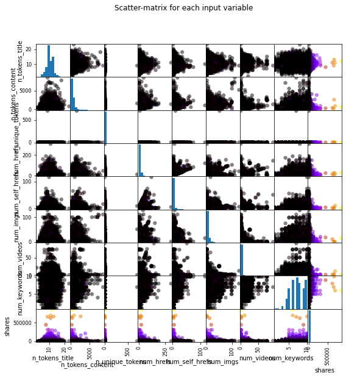

```python
#Creating a Scatter Matrix for Correlation Analysis:

#Importing Scatter Matrix from the Pandas library:
import pandas as pd
from pandas.plotting import scatter_matrix
import matplotlib.pyplot as plt
from matplotlib import cm


#Best 10 numerical attributes:
numeric = ['n_tokens_title', 'n_tokens_content', 'n_unique_tokens',
           'num_hrefs', 'num_self_hrefs', 'num_imgs',
           'num_videos', 'num_keywords', 'shares']
X = df[numeric]
y = df['shares']
cmap = cm.get_cmap('gnuplot')
scatter = scatter_matrix(X, c = y, marker = 'o', s=40,
                         hist_kwds={'bins':15}, figsize=(9,9), cmap = cmap)
plt.suptitle('Scatter-matrix for each input variable')
plt.savefig('Numeric_Scatter_Matrix')
```

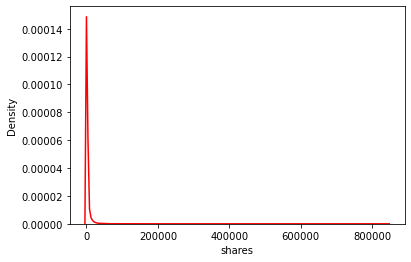

```python
#Exploring the data:
import seaborn as sns

sns.kdeplot(df['shares'], color="red")
#The data is right skewed with a lower bound
```

## Task 2

Split the dataset into a training set (70%) and a test set (30%) and apply scaling, etc (similar to lab)

```python
#Create Training and Test Sets splits:
#Applying Scaling:
from sklearn.model_selection import train_test_split
from sklearn.preprocessing import MinMaxScaler

X_train, X_test, y_train, y_test = train_test_split(X, y, test_size=0.3, random_state=0)

scaler = MinMaxScaler()
X_train = scaler.fit_transform(X_train)
X_test = scaler.transform(X_test)
print("Data sets are split and scaled!")
```

```
Data sets are split and scaled!
```

## Task 3

Train k-NN for k=3,5,7,9,11 and calculate runtime and accuracy for each *k*. (You can repeat code multiple times for different *k*, by setting `n_neighbors` in code as described [here](https://scikit-learn.org/stable/modules/generated/sklearn.neighbors.KNeighborsClassifier.html))

```python
#Training a KNN model where k=3:
#Overall Run-time for all of the KNN functions:
from datetime import datetime
start_time = datetime.now()

from sklearn.neighbors import KNeighborsClassifier
knn = KNeighborsClassifier(n_neighbors=3)
knn.fit(X_train, y_train)
print('Accuracy of K-NN=3 classifier on training set: {:.2f}'
     .format(knn.score(X_train, y_train)))
print('Accuracy of K-NN=3 classifier on test set: {:.2f}'
     .format(knn.score(X_test, y_test)))


#===================================================================
print("\n========================================================\n")

#Training a KNN model where k=5:

from sklearn.neighbors import NearestNeighbors
knn = KNeighborsClassifier(n_neighbors=5)
knn.fit(X_train, y_train)
print('Accuracy of K-NN=5 classifier on training set: {:.2f}'
     .format(knn.score(X_train, y_train)))
print('Accuracy of K-NN=5 classifier on test set: {:.2f}'
     .format(knn.score(X_test, y_test)))


#===================================================================
print("\n========================================================\n")

#Training a KNN model where k=7:

from sklearn.neighbors import NearestNeighbors
knn = KNeighborsClassifier(n_neighbors=7)
knn.fit(X_train, y_train)
print('Accuracy of K-NN=7 classifier on training set: {:.2f}'
     .format(knn.score(X_train, y_train)))
print('Accuracy of K-NN=7 classifier on test set: {:.2f}'
     .format(knn.score(X_test, y_test)))

#===================================================================
print("\n========================================================\n")

#Training a KNN model where k=9:

from sklearn.neighbors import NearestNeighbors
knn = KNeighborsClassifier(n_neighbors=9)
knn.fit(X_train, y_train)
print('Accuracy of K-NN=9 classifier on training set: {:.2f}'
     .format(knn.score(X_train, y_train)))
print('Accuracy of K-NN=9 classifier on test set: {:.2f}'
     .format(knn.score(X_test, y_test)))

#===================================================================
print("\n========================================================\n")

#Training a KNN model where k=11:

from sklearn.neighbors import NearestNeighbors
knn = KNeighborsClassifier(n_neighbors=11)
knn.fit(X_train, y_train)
print('Accuracy of K-NN=11 classifier on training set: {:.2f}'
     .format(knn.score(X_train, y_train)))
print('Accuracy of K-NN=11 classifier on test set: {:.2f}'
     .format(knn.score(X_test, y_test)))

#===================================================================
print("\n========================================================\n")

end_time = datetime.now()
print('The overall duration for the KNN is: {}'.format(end_time - start_time))
```

```
Accuracy of K-NN=3 classifier on training set: 0.33
Accuracy of K-NN=3 classifier on test set: 0.02

========================================================

Accuracy of K-NN=5 classifier on training set: 0.22
Accuracy of K-NN=5 classifier on test set: 0.01

========================================================

Accuracy of K-NN=7 classifier on training set: 0.18
Accuracy of K-NN=7 classifier on test set: 0.01

========================================================

Accuracy of K-NN=9 classifier on training set: 0.16
Accuracy of K-NN=9 classifier on test set: 0.02

========================================================

Accuracy of K-NN=11 classifier on training set: 0.15
Accuracy of K-NN=11 classifier on test set: 0.03

========================================================

The overall duration for the KNN is: 0:00:22.289998
```

```python
#Run-time for a KNN functions:
start_time = datetime.now()

from sklearn.neighbors import NearestNeighbors
knn = KNeighborsClassifier(n_neighbors=5)
knn.fit(X_train, y_train)
print('Accuracy of K-NN=5 classifier on training set: {:.2f}'
     .format(knn.score(X_train, y_train)))
print('Accuracy of K-NN=5 classifier on test set: {:.2f}'
     .format(knn.score(X_test, y_test)))


#===================================================================
print("\n========================================================\n")

end_time = datetime.now()
print('The overall duration for the KNN is: {}'.format(end_time - start_time))
```

```
Accuracy of K-NN=5 classifier on training set: 0.22
Accuracy of K-NN=5 classifier on test set: 0.01

========================================================

The overall duration for the KNN is: 0:00:03.417020
```

## Task 4

Train SVM similar to the lab document and calculate runtime and accuracy

```python
#Support Vector Machine:
#The Run-time for the SVM model:
start_time = datetime.now()

from sklearn.svm import SVC
svm = SVC()
svm.fit(X_train, y_train)
print('Accuracy of SVM classifier on training set: {:.2f}'
     .format(svm.score(X_train, y_train)))
print('Accuracy of SVM classifier on test set: {:.2f}'
     .format(svm.score(X_test, y_test)))

#===================================================================
print("\n========================================================\n")

end_time = datetime.now()
print('The overall duration for the SVM model is: {}'
      .format(end_time - start_time))
```

```
Accuracy of SVM classifier on training set: 0.06
Accuracy of SVM classifier on test set: 0.06

========================================================

The overall duration for the SVM model is: 0:44:10.883601
```

```python
#The Confusion matrix for SVM model:

from sklearn.metrics import classification_report
from sklearn.metrics import confusion_matrix
pred = svm.predict(X_test)
print(confusion_matrix(y_test, pred))
print(classification_report(y_test, pred))
```

```
[[0 0 0 ... 0 0 0]
 [0 0 0 ... 0 0 0]
 [0 0 0 ... 0 0 0]
 ...
 [0 0 0 ... 0 0 0]
 [0 0 0 ... 0 0 0]
 [0 0 0 ... 0 0 0]]
              precision    recall  f1-score   support

           1       0.00      0.00      0.00         1
          22       0.00      0.00      0.00         1
          41       0.00      0.00      0.00         1
          42       0.00      0.00      0.00         1
          52       0.00      0.00      0.00         1
          54       0.00      0.00      0.00         1
```

[output cut: 1025 more lines]

## Task 5

Train Decision Tree similar to the lab document and calculate runtime and accuracy

```python
#Decision Tree model:
#The Run-time for the Decision Tree model:
start_time = datetime.now()

from sklearn.tree import DecisionTreeClassifier
clf = DecisionTreeClassifier().fit(X_train, y_train)
print('Accuracy of Decision Tree classifier on training set: {:.2f}'
     .format(clf.score(X_train, y_train)))
print('Accuracy of Decision Tree classifier on test set: {:.2f}'
     .format(clf.score(X_test, y_test)))

#===================================================================
print("\n========================================================\n")

end_time = datetime.now()
print('The overall duration for the Decision Tree model is: {}'
      .format(end_time - start_time))
```

```
Accuracy of Decision Tree classifier on training set: 1.00
Accuracy of Decision Tree classifier on test set: 0.98

========================================================

The overall duration for the Decision Tree model is: 0:00:02.561299
```

# Adding a Simple Linear Regression Model

```python
#Simple Linear Regression model:
#The Run-time for the SLR model:
start_time = datetime.now()

from sklearn import linear_model
slc = linear_model.LinearRegression().fit(X_train, y_train)
print('Accuracy of Decision Tree classifier on training set: {:.2f}'
     .format(slc.score(X_train, y_train)))
print('Accuracy of Decision Tree classifier on test set: {:.2f}'
     .format(slc.score(X_test, y_test)))

#===================================================================
print("\n========================================================\n")

end_time = datetime.now()
print('The overall duration for the SLR model is: {}'
      .format(end_time - start_time))
```

```
Accuracy of Decision Tree classifier on training set: 1.00
Accuracy of Decision Tree classifier on test set: 1.00

========================================================

The overall duration for the SLR model is: 0:00:00.014958
```

# Adding a Multiple Linear Regression Model

```
Coefficients:
 [ 2.77832566e-12 -5.94522100e-11  2.65992568e-12 -1.23737137e-10
 -6.17109396e-11  1.79048806e-10 -1.04667150e-10 -2.30107690e-11
  8.43296000e+05]
Variance Score: 1.0
```

[output not shown]

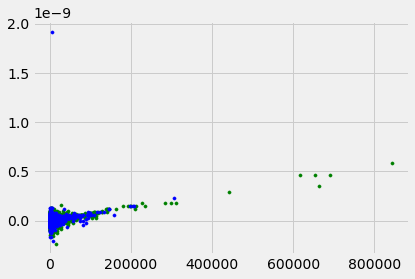

```python
#Multiple Linear Regression model:
from sklearn import metrics
import matplotlib.pyplot as plt
slc = linear_model.LinearRegression().fit(X_train, y_train)
print('Coefficients: \n' , slc.coef_)
print('Variance Score: {}'.format(slc.score(X_test, y_test)))
plt.style.use('fivethirtyeight')
plt.scatter(slc.predict(X_train), slc.predict(X_train) - y_train, color = 'green',
           s = 10, label = 'Train Data')
plt.scatter(slc.predict(X_test), slc.predict(X_test) - y_test, color = 'blue',
           s = 10, label = 'Test Data')
plt.hlines(y=0, xmin=0, xmax=50, linewidth=2)
plt.legend(loc='Upper Right')
plt.title('Residual Errors')
plt.show()
```

## Task 6 - Complete the summary

Complete this cell (if there is a tie in results, report all of them):

**Hint**: The low accuracy/performance is NOT important in this project. Just make sure you follow right steps, and report based on what you found

**NOTE: The SLR model had the absolute shortest runtime when compared to the other three models with less than a second.**

**-The SLR model had 100% accuracy for both the training and test data.**